# ラ・リーガの各チームの強さを推定する(モデル3)

UPDATE: 2024-01-23 19:38:41.665144

# はじめに

このノートは「ベイズ統計」に関する何らかの内容をまとめ、ベイズ統計への理解を深めていくために作成している。今回はRasmus Bååth先生のブログに記載されているサッカーチームの強さを推定する内容を参考にさせていただき、写経しながら、ところどころ自分用の補足をメモすることで、自分用の補足資料になることを目指す。私の解釈がおかしく、メモが誤っている場合があるので注意。

- [Modeling Match Results in La Liga Using a Hierarchical Bayesian Poisson Model: Part one.](https://www.sumsar.net/blog/2013/07/modeling-match-results-in-la-liga-part-one/)
- [Modeling Match Results in La Liga Using a Hierarchical Bayesian Poisson Model: Part two.](https://www.sumsar.net/blog/2013/07/modeling-match-results-in-la-liga-part-two/)
- [Modeling Match Results in La Liga Using a Hierarchical Bayesian Poisson Model: Part three](https://www.sumsar.net/blog/2013/08/modeling-match-results-in-la-liga-part-three/)

こちらのブログではJAGSを利用しており、再現はStanで行うため、結果は完全に一致しない。また、JAGSとStanでは正規分布のパラメタの与え方が異なるので、そのあたりは修正を行っているが、ブログの数式はそのまま表示しているので、数式とStanモデルでは差異がある点は注意が必要である。

1つ前のノートでは、ブログをStanで再現することを中心にしていたため、データをサンプリングしていたが、ここではサンプリングせずにパラメタを推定する。また、モデル3を中心にメカニズムを深掘りしておく。

# 準備

まずは必要なデータやパッケージを準備しておく。ブログで使用されている通り、使用するデータはラ・リーガの5つのシーズン(`2008/09, 2009/10, 2010/11, 2011/12, 2012/13`)の試合結果が記録されているデータを利用する。

```r
library(tidyverse)
library(rstan)
library(patchwork)

options(max.print = 999999)
rstan_options(auto_write=TRUE)
options(mc.cores=parallel::detectCores())
load("laliga.RData")
head(laliga)
```

```
##    Season Week               HomeTeam                    AwayTeam HomeGoals
## 1 2008/09    1   Athletic Club Bilbao     Union Deportiva Almeria         1
## 2 2008/09    1        Atlético Madrid                   Málaga CF         4
## 3 2008/09    1          Betis Sevilla Real Club Recreativo Huelva         0
## 4 2008/09    1             CA Osasuna               Villarreal CF         1
## 5 2008/09    1            CD Numancia                FC Barcelona         1
## 6 2008/09    1 Deportivo de La Coruña              Real Madrid CF         2
##   AwayGoals
## 1         3
## 2         0
## 3         1
## 4         1
## 5         0
## 6         1
```

モデリングや可視化で必要になるカラムを作成しておく。`2012/13`シーズンのいくつかのレコードには欠損値が含まれているので、そのレコードは除外しておく。

```r
d <- na.omit(laliga)
dim(d)
```

```
## [1] 1850    6
```

```r
teams <- unique(c(d$HomeTeam, d$AwayTeam))
seasons <- unique(d$Season)

data_list <- list(
  HomeGoals = d$HomeGoals,
  AwayGoals = d$AwayGoals,
  HomeTeam = as.numeric(factor(d$HomeTeam, levels = teams)),
  AwayTeam = as.numeric(factor(d$AwayTeam, levels = teams)),
  Season = as.numeric(factor(d$Season, levels=seasons)),
  n_teams = length(teams),
  n_games = nrow(d),
  n_seasons = length(seasons)
  )

map(.x = data_list,.f = function(x){head(x,100)})
```

```
## $HomeGoals
##   [1] 1 4 0 1 1 2 1 3 1 1 1 4 0 0 1 0 4 2 2 1 2 4 0 1 0 1 1 0 1 1 0 3 2 1 0 2 1
##  [38] 7 2 2 0 0 1 0 1 4 2 1 0 1 0 1 6 4 2 0 0 2 0 2 0 1 3 0 4 2 0 1 2 0 0 2 0 5
##  [75] 0 1 3 1 3 4 1 2 0 1 2 1 1 3 3 1 0 2 1 6 1 0 3 1 4 2
##
## $AwayGoals
##   [1] 3 0 1 1 0 1 0 0 1 2 1 3 0 0 1 1 3 1 2 0 0 0 0 2 0 1 0 2 6 0 0 2 0 2 2 0 1
##  [38] 1 0 0 1 1 2 0 2 2 1 2 1 0 1 0 1 0 2 2 4 2 1 1 1 2 0 0 0 1 0 1 1 1 2 1 3 0
##  [75] 1 0 0 1 2 4 4 0 3 0 4 4 1 2 1 1 0 4 0 0 0 3 3 0 3 1
##
## $HomeTeam
##   [1]  1  2  3  4  5  6  7  8  9 10 11 12 13 14 15 16 17 18 19 20  1  2  3  5  6
##  [26]  7  8  9 10 19  4 11 12 13 14 15 16 17 18 20  1  2  3  5  7  8 14  9 10 19
##  [51]  4  6 11 12 13 15 16 17 18 20  1  2  3  7  8 14  9 18 10 19  4  5  6 11 12
##  [76] 13 15 16 17 20  1  2  3  7  8 14 16 18 10 19  4  5  6 11 12 13 15  9 17 20
##
## $AwayTeam
##   [1] 19 14 16 20 11 17 18 15 12 13  9 10  3  1  4  7  5  2  8  6 18 16 12 20 15
##  [26] 13  4 17 11 14  6  3  7  2  8  5  1 10 19  9 13 12 17  4 11  6 18 15 20 16
##  [51]  9  5  2  1 19 10 14  7  8  3 11 17 15 20  5 13  6 16  4 12  3  9 10 19 14
##  [76] 18  7  8  1  2 20 15  6  4  9 11 13 12  5 17  2  3  7 18 16  8  1 10 14 19
##
## $Season
##   [1] 1 1 1 1 1 1 1 1 1 1 1 1 1 1 1 1 1 1 1 1 1 1 1 1 1 1 1 1 1 1 1 1 1 1 1 1 1
##  [38] 1 1 1 1 1 1 1 1 1 1 1 1 1 1 1 1 1 1 1 1 1 1 1 1 1 1 1 1 1 1 1 1 1 1 1 1 1
##  [75] 1 1 1 1 1 1 1 1 1 1 1 1 1 1 1 1 1 1 1 1 1 1 1 1 1 1
##
## $n_teams
## [1] 29
##
## $n_games
## [1] 1850
##
## $n_seasons
## [1] 5
```

数字とチーム名の対応は下記の通りである。

```r
data.frame(
  no = as.numeric(factor(unique(d$HomeTeam), levels=teams)),
  teams
  )
```

```
##    no                                       teams
## 1   1                        Athletic Club Bilbao
## 2   2                             Atlético Madrid
## 3   3                               Betis Sevilla
## 4   4                                  CA Osasuna
## 5   5                                 CD Numancia
## 6   6                      Deportivo de La Coruña
## 7   7                          Espanyol Barcelona
## 8   8                                 FC Valencia
## 9   9                            Racing Santander
## 10 10                              Sporting Gijón
## 11 11                                FC Barcelona
## 12 12                                  FC Sevilla
## 13 13                                   Getafe CF
## 14 14                                   Málaga CF
## 15 15                                RCD Mallorca
## 16 16                 Real Club Recreativo Huelva
## 17 17                              Real Madrid CF
## 18 18                             Real Valladolid
## 19 19                     Union Deportiva Almeria
## 20 20                               Villarreal CF
## 21 21                               Real Zaragoza
## 22 22                                 CD Tenerife
## 23 23 Club Deportivo Xeres / Jerez de la Frontera
## 24 24                        Hércules Alicante CF
## 25 25                                Levante U.D.
## 26 26                 Real Sociedad San Sebastian
## 27 27                              Rayo Vallecano
## 28 28                                  Granada CF
## 29 29                                  Celta Vigo
```

メカニズムは下記の図の通り。

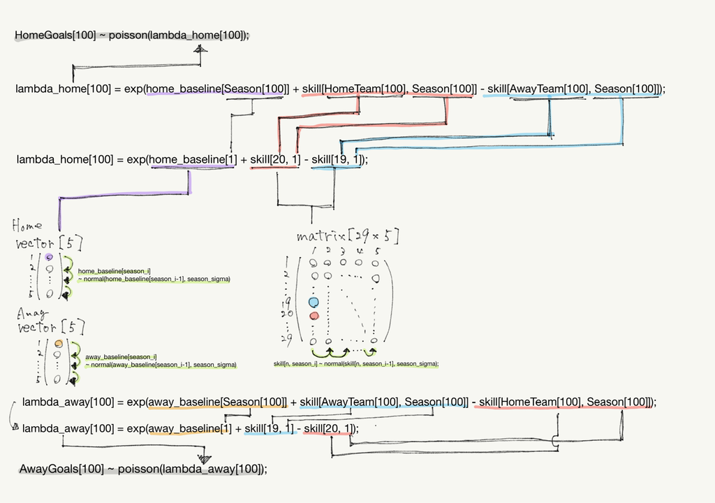

モデルはこちら。

```
data {
  int<lower=1> n_games;             // 1850
  int<lower=1> n_seasons;           // 5
  int<lower=1> n_teams;             // 29
  int<lower=1> Season[n_games];
  int<lower=1> HomeTeam[n_games];
  int<lower=1> AwayTeam[n_games];
  int<lower=0> HomeGoals[n_games];
  int<lower=0> AwayGoals[n_games];
}
parameters {
  vector[n_seasons] home_baseline;
  vector[n_seasons] away_baseline;
  matrix[n_teams, n_seasons] skill;
  real<lower=0> group_sigma;
  real<lower=0> season_sigma;
}

transformed parameters {
  vector[n_games] lambda_home;
  vector[n_games] lambda_away;

  for (i in 1:n_games) {
    lambda_home[i] = exp(home_baseline[Season[i]] + skill[HomeTeam[i], Season[i]] - skill[AwayTeam[i], Season[i]]);
    lambda_away[i] = exp(away_baseline[Season[i]] + skill[AwayTeam[i], Season[i]] - skill[HomeTeam[i], Season[i]]);
  }
}
model {
  group_sigma ~ uniform(0, 1000);
  home_baseline[1] ~ normal(0, 4);
  away_baseline[1] ~ normal(0, 4);

  for (n in 1:n_teams) {
    skill[n, 1] ~ normal(0, group_sigma);
  }

  for (season_i in 2:n_seasons) {
    for (n in 1:n_teams) {
      skill[n, season_i] ~ normal(skill[n, season_i-1], season_sigma);
      }
    home_baseline[season_i] ~ normal(home_baseline[season_i-1], season_sigma);
    away_baseline[season_i] ~ normal(away_baseline[season_i-1], season_sigma);
  }

  for (i in 1:n_games) {
    HomeGoals[i] ~ poisson(lambda_home[i]);
    AwayGoals[i] ~ poisson(lambda_away[i]);
  }
}
```

`sampling()`関数でサンプリングする。

```r
model3 <- stan_model('model3.stan')
fit3 <- sampling(object = model3, data = data_list, seed = 1989, chains = 4, iter = 10000, thin = 5)
```

推定結果を確認する。

```r
print(fit3, prob = c(0.025, 0.5, 0.975), digits_summary = 3)
```

```
## Inference for Stan model: anon_model.
## 4 chains, each with iter=10000; warmup=5000; thin=5;
## post-warmup draws per chain=1000, total post-warmup draws=4000.
##
##                        mean se_mean     sd      2.5%       50%     97.5% n_eff
## home_baseline[1]      0.450   0.001  0.032     0.389     0.449     0.513  3580
## home_baseline[2]      0.435   0.001  0.029     0.376     0.436     0.492  3183
## home_baseline[3]      0.443   0.000  0.028     0.386     0.444     0.498  3672
## home_baseline[4]      0.453   0.000  0.028     0.397     0.453     0.508  3933
## home_baseline[5]      0.456   0.001  0.033     0.392     0.457     0.520  3785
## away_baseline[1]      0.119   0.001  0.039     0.046     0.118     0.198  1378
## away_baseline[2]      0.079   0.001  0.032     0.014     0.079     0.140  3908
## away_baseline[3]      0.063   0.001  0.032    -0.006     0.064     0.124  3137
## away_baseline[4]      0.058   0.001  0.034    -0.012     0.060     0.121  2414
## away_baseline[5]      0.080   0.001  0.038     0.006     0.080     0.156  4092
## skill[1,1]           -0.024   0.001  0.070    -0.157    -0.026     0.115  2550
## skill[1,2]           -0.010   0.001  0.067    -0.137    -0.012     0.122  2423
## skill[1,3]           -0.001   0.001  0.066    -0.128    -0.001     0.130  2360
## skill[1,4]           -0.011   0.001  0.068    -0.141    -0.013     0.126  2658
## skill[1,5]           -0.034   0.001  0.075    -0.187    -0.034     0.114  2613
## skill[2,1]            0.156   0.001  0.070     0.019     0.156     0.293  2876
## skill[2,2]            0.142   0.001  0.067     0.008     0.143     0.272  2244
## skill[2,3]            0.159   0.001  0.067     0.028     0.158     0.290  2642
## skill[2,4]            0.179   0.001  0.068     0.049     0.178     0.313  2789
## skill[2,5]            0.211   0.002  0.076     0.068     0.209     0.367  1897
## skill[3,1]           -0.006   0.001  0.077    -0.158    -0.007     0.145  2846
## skill[3,2]           -0.003   0.001  0.080    -0.161    -0.004     0.156  3038
## skill[3,3]           -0.001   0.001  0.079    -0.156    -0.001     0.154  3009
## skill[3,4]            0.002   0.001  0.074    -0.144     0.002     0.146  2626
## skill[3,5]            0.009   0.002  0.079    -0.142     0.008     0.168  2564
## skill[4,1]           -0.022   0.001  0.068    -0.153    -0.022     0.115  2637
## skill[4,2]           -0.025   0.001  0.064    -0.144    -0.025     0.107  2622
## skill[4,3]           -0.024   0.001  0.065    -0.146    -0.024     0.107  2636
## skill[4,4]           -0.038   0.001  0.067    -0.171    -0.039     0.093  2510
## skill[4,5]           -0.041   0.001  0.074    -0.183    -0.040     0.103  2741
## skill[5,1]           -0.192   0.002  0.094    -0.377    -0.193    -0.003  3539
## skill[5,2]           -0.193   0.002  0.105    -0.399    -0.192     0.017  3515
## skill[5,3]           -0.193   0.002  0.115    -0.418    -0.193     0.030  3524
## skill[5,4]           -0.193   0.002  0.123    -0.431    -0.194     0.052  3604
## skill[5,5]           -0.193   0.002  0.132    -0.458    -0.194     0.074  3629
```

[output cut: 7672 more lines]

```
## lambda_away[1842] 0.999
## lambda_away[1843] 1.001
## lambda_away[1844] 1.000
## lambda_away[1845] 1.001
## lambda_away[1846] 1.003
## lambda_away[1847] 1.000
## lambda_away[1848] 1.000
## lambda_away[1849] 1.000
## lambda_away[1850] 1.000
## lp__              1.022
##
## Samples were drawn using NUTS(diag_e) at Tue Jan 23 19:43:49 2024.
## For each parameter, n_eff is a crude measure of effective sample size,
## and Rhat is the potential scale reduction factor on split chains (at
## convergence, Rhat=1).
```

各チームのスキルの時系列の推移を可視化しておく。

```r
ms3 <- rstan::extract(fit3)
d_est <- data.frame()
for (n in 1:length(teams)) {
  qua <- apply(ms3$skill[,n,], 2, quantile, prob  =  c(0.25, 0.5, 0.75))
  d_est <- rbind(
     d_est,
     data.frame(team = teams[n], year = 2008:2012, t(qua), check.names = FALSE)
     )
}

d_est_target <- d_est %>%
  filter(team %in% c(
    "Atlético Madrid",
    "FC Valencia",
    #"FC Barcelona",
    #"Real Madrid CF",
    "Villarreal CF",
    "Real Sociedad San Sebastian"
  ))
```

今回のデータセットの時期における実績は下記の通りで、圧倒的にバルセロナ、レアル・マドリードが優位であるので、このチームを除いて可視化した結果も記載しておく。

- 2008-09: バルセロナ / レアル・マドリード
- 2009-10: バルセロナ / レアル・マドリード
- 2010-11: バルセロナ / レアル・マドリード
- 2011-12: レアル・マドリード / バルセロナ
- 2012-13: バルセロナ / レアル・マドリード

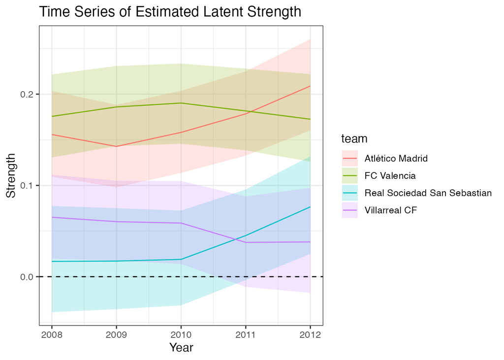

```r
ggplot(data = d_est_target, aes(x = year, y = `50%`, group = team)) +
  theme_bw(base_size = 12) +
  geom_ribbon(aes(ymin = `25%`, ymax = `75%`, fill = team), alpha = 0.2) +
  geom_line(aes(col = team), linewidth = 0.5) +
  geom_hline(yintercept = 0, linetype = 'dashed') +
  labs(x = 'Year', y = 'Strength', title = 'Time Series of Estimated Latent Strength') +
  scale_x_continuous(breaks = 2008:2012)
```